# Trabajo Final

Mateo Larco

2 de agosto de 2015

*2.- Genere un archivo rlm.R, de tal forma que le permita responder las siguientes preguntas:*

*2.1.- Leer los archivos poblacion1.xlsx y poblacion2.xlsx , y analizar sus dimensiones.*

|  | identificador | poblacion | var.pobl.mayor | menores.18 |
| --- | --- | --- | --- | --- |
| 1 | 1001 | 18.7 | 6.2 | 39.7 |
| 2 | 1002 | 13.8 | 7.2 | 10.4 |
| 3 | 1003 | 13.4 | 7.1 | 20.4 |
| 4 | 1004 | 11.4 | 2.6 | 38.7 |
| 5 | 1005 | 10.5 | 2.8 | 36.4 |
| 6 | 1006 | 10.3 | 1.4 | 29.8 |
| 7 | 1007 | 10.3 | -0.5 | 31.8 |
| 8 | 1008 | 10.3 | 3 | 31.1 |
| 9 | 1009 | 10.3 | -1.9 | 15.9 |
| 10 | 1010 | 9.4 | -1.5 | 22.4 |

[output cut: 34 more lines]

|  | identificador | part.almz.escl | var.ingresos | tasa.crimen | var.tasa.crimen | region | serv.bas.compl |
| --- | --- | --- | --- | --- | --- | --- | --- |
| 1 | 1044 | 73.8 | 50.5 | 704.1 | -40.9 | B | SI |
| 2 | 1042 | 34.4 | 24.2 | 179.9 | 12.3 | B | NO |
| 3 | 1010 | 22.2 | 33.5 | 61.5 | -32.7 | A | NO |
| 4 | 1009 | 39.9 | 38.5 | 86.4 | -13.5 | A | SI |
| 5 | 1008 | 51.7 | 26.2 | 42.4 | -31.9 | A | NO |
| 6 | 1007 | 57.2 | 27.2 | 61.2 | -17.6 | A | NO |
| 7 | 1006 | 43.7 | 29.4 | 54 | -10 | A | NO |
| 8 | 1005 | 72.3 | 26 | 77.5 | -21.6 | A | SI |
| 9 | 1004 | 78.2 | 18.4 | 86.6 | -12.8 | A | NO |
| 10 | 1003 | 13.9 | 22.5 | 38.3 | -33.6 | A | NO |

[output cut: 30 more lines]

Analizando la información de población1 disponemos de 44 observaciones de 4 variables. De la misma forma, analizando la información de la población2 disponemos de 40 observaciones de 7 variables.

*2.2.- Una los archivos leídos en un mismo objeto llamado población.*

Usamos merge para unir las poblaciones:

|  | identificador | poblacion | var.pobl.mayor | menores.18 | part.almz.escl | var.ingresos | tasa.crimen | var.tasa.crimen | region | serv.bas.compl |
| --- | --- | --- | --- | --- | --- | --- | --- | --- | --- | --- |
| 1 | 1001 | 18.7 | 6.2 | 39.7 | 55.8 | 28.7 | 52.6 | -2.9 | A | SI |
| 2 | 1002 | 13.8 | 7.2 | 10.4 | 57.9 | 26.2 | 111 | -22.6 | A | SI |
| 3 | 1003 | 13.4 | 7.1 | 20.4 | 13.9 | 22.5 | 38.3 | -33.6 | A | NO |
| 4 | 1004 | 11.4 | 2.6 | 38.7 | 78.2 | 18.4 | 86.6 | -12.8 | A | NO |
| 5 | 1005 | 10.5 | 2.8 | 36.4 | 72.3 | 26 | 77.5 | -21.6 | A | SI |
| 6 | 1006 | 10.3 | 1.4 | 29.8 | 43.7 | 29.4 | 54 | -10 | A | NO |
| 7 | 1007 | 10.3 | -0.5 | 31.8 | 57.2 | 27.2 | 61.2 | -17.6 | A | NO |
| 8 | 1008 | 10.3 | 3 | 31.1 | 51.7 | 26.2 | 42.4 | -31.9 | A | NO |
| 9 | 1009 | 10.3 | -1.9 | 15.9 | 39.9 | 38.5 | 86.4 | -13.5 | A | SI |
| 10 | 1010 | 9.4 | -1.5 | 22.4 | 22.2 | 33.5 | 61.5 | -32.7 | A | NO |

[output cut: 30 more lines]

*2.3.- Cree un código que identiﬁque la clase de cada variable y genere diagramas de cajas para variables continuas y diagramas de barras para variables discretas.*

Variables continuas:

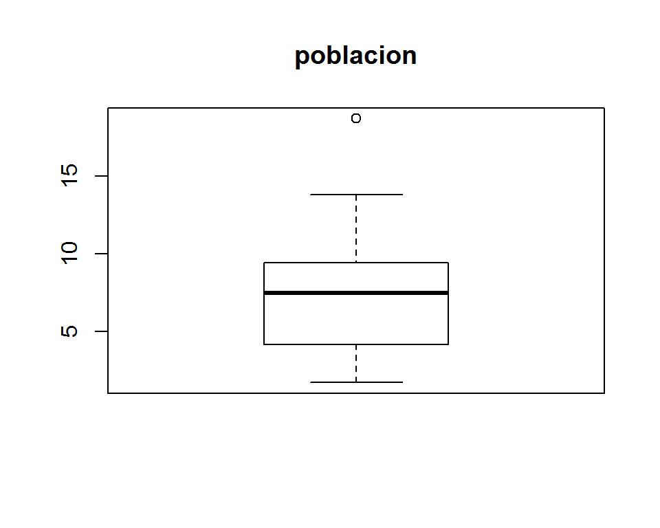

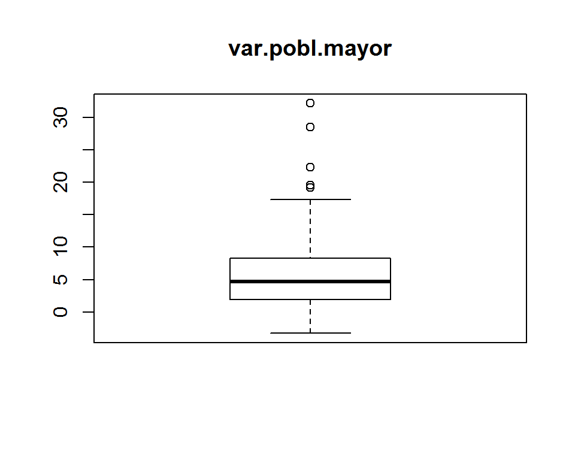

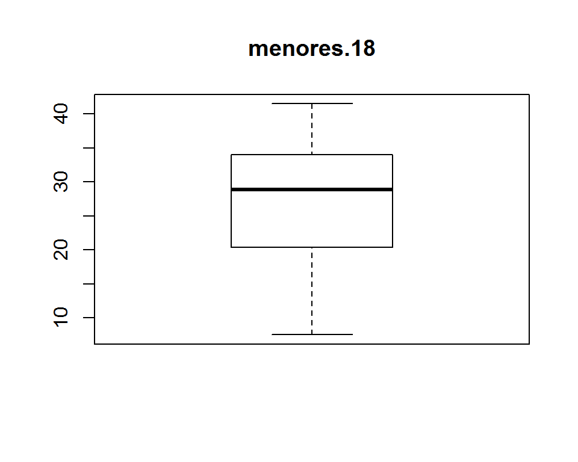

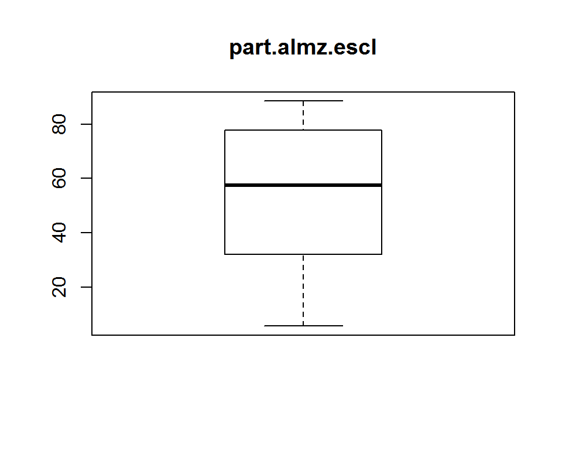

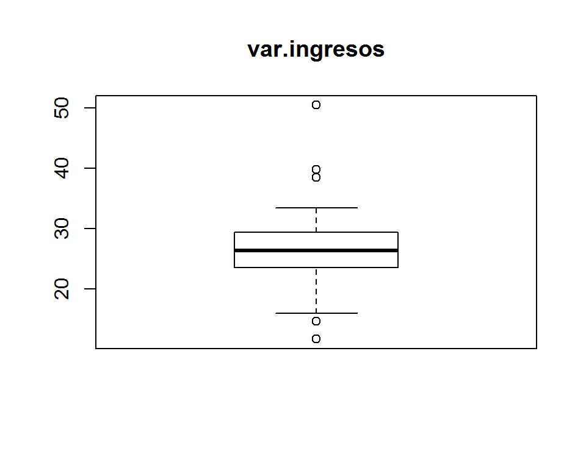

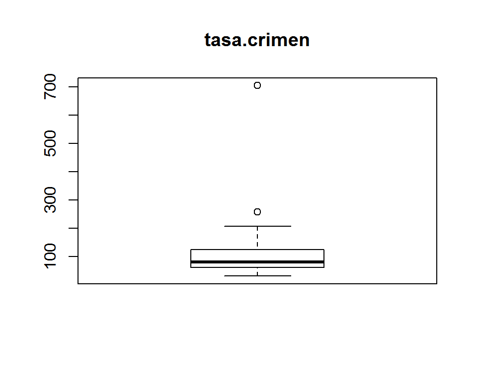

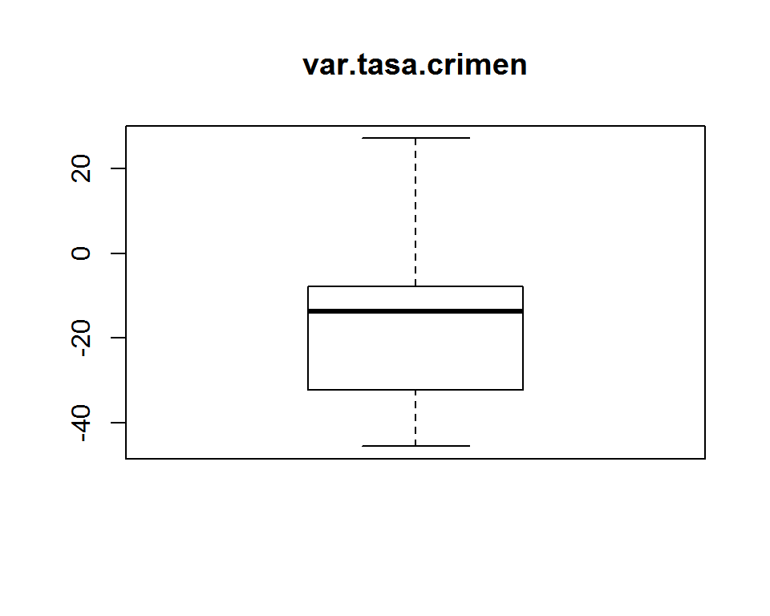

```r
for(j in 2:dim(poblacion)[2]){
  if(is.numeric(poblacion[,j])==TRUE){
    boxplot(poblacion[,j])
    title(names(poblacion)[j])
  }
}
```

Variables discretas:

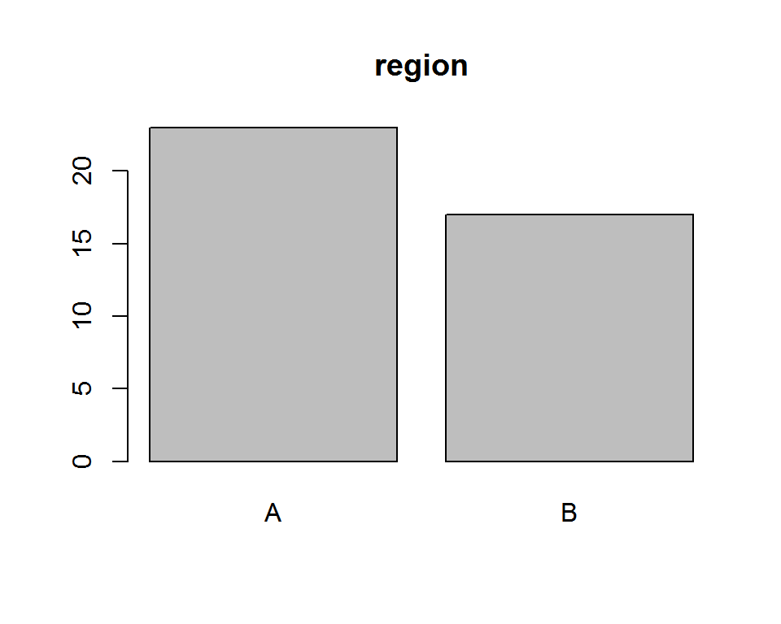

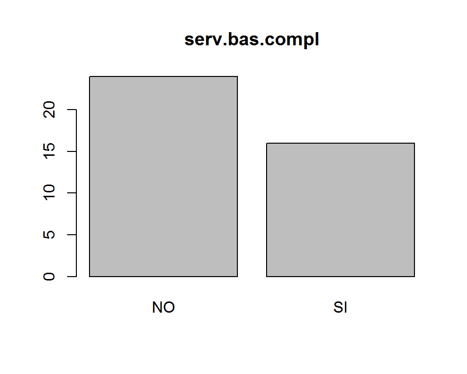

```r
for(j in 2:dim(poblacion)[2]){
  if(is.numeric(poblacion[,j])!=TRUE){
    barplot(table(poblacion[,j]))
    title(names(poblacion)[j])
  }
}
```

*2.4.- Cree un código que calcule automáticamente el mínimo, media, máximo, desviación estándar, primer cuartil de cada variable numérica y la frecuencia en el caso de variables categóricas.*

|  | names.poblacion. | tipo | maxi | mini | media | desviacion | primer_cuartil |
| --- | --- | --- | --- | --- | --- | --- | --- |
| 1 | identificador | 1 | 1 | 1 | 1 | 1 | 1 |
| 2 | poblacion | numeric | 18.7 | 1.7 | 7.2325 | 3.6214027244022 | 4.175 |
| 3 | var.pobl.mayor | numeric | 32.2 | -3.3 | 6.6475 | 8.14877645369584 | 1.975 |
| 4 | menores.18 | numeric | 41.5 | 7.5 | 27.0725 | 9.03633654780123 | 20.375 |
| 5 | part.almz.escl | numeric | 88.5 | 5.7 | 53.175 | 25.4207844499591 | 33.25 |
| 6 | var.ingresos | numeric | 50.5 | 11.7 | 26.7875 | 6.85416540020252 | 23.65 |
| 7 | tasa.crimen | numeric | 704.1 | 32 | 111.035 | 108.88913333742 | 62.325 |
| 8 | var.tasa.crimen | numeric | 27.2 | -45.6 | -15.9625 | 15.7586229956157 | -32.05 |
| 9 | region | character |  |  |  |  |  |
| 10 | serv.bas.compl | character |  |  |  |  |  |

Ahora considerando las variables categoricas “region” y “serv.bas.compl” calculamos sus frecuencias:

```
##
##     A     B
## 0.575 0.425
```

```
##
##  NO  SI
## 0.6 0.4
```

*2.5.- Calcule la correlación entre la variable dependiente poblacion y cada una de las variables explicativas (numéricas).*

Ahora la correlación con cada variable será:

|  | names.poblacion. | correlacion |
| --- | --- | --- |
| 1 | identificador |  |
| 2 | poblacion | 1 |
| 3 | var.pobl.mayor | -0.157740307336422 |
| 4 | menores.18 | 0.19709059035665 |
| 5 | part.almz.escl | -0.0468617217051812 |
| 6 | var.ingresos | -0.0767770820467971 |
| 7 | tasa.crimen | -0.374922537800256 |
| 8 | var.tasa.crimen | -0.0764530102296091 |
| 9 | region |  |
| 10 | serv.bas.compl |  |

*2.6.- Considere la variable categórica serv.bas.compl con una conﬁabilidad del 90%, ¿Puede asumirse que la media de la variable poblacion en el grupo serv.bas.compl: SI es distinta a la media del grupo serv.bas.compl: NO ?*

Transformo a variable factor las columnas “region” y “serv.bas.compl” para poder usar el test t(student)

```r
serv.bas.compl_fac <- factor(poblacion[,"serv.bas.compl"],levels=c("SI","NO"),labels=c("si","no"))
region_fac <- factor(poblacion[,"region"],levels=c("A","B"),labels=c("a","b"))
poblacion_fac <- data.frame(poblacion[,1:7],region_fac,serv.bas.compl_fac)
```

Diagrama de cajas:

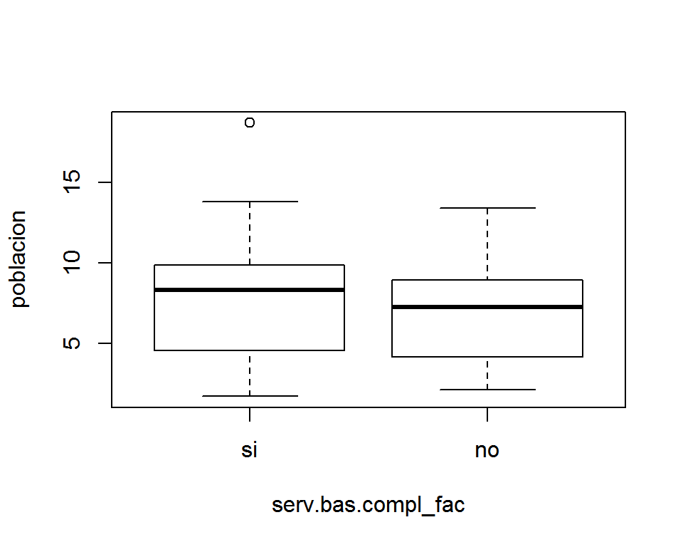

```r
plot(poblacion ~ serv.bas.compl_fac , data = poblacion_fac)
```

Por último realizamos la prueba de hipotesis:

```
##
##  Welch Two Sample t-test
##
## data:  poblacion by serv.bas.compl_fac
## t = 0.91985, df = 24.672, p-value = 0.3666
## alternative hypothesis: true difference in means is not equal to 0
## 90 percent confidence interval:
##  -0.9901808  3.2985141
## sample estimates:
## mean in group si mean in group no
##         7.925000         6.770833
```

Concluimos que se acepta que la diferencia de medias es igual a cero.

*2.7.- Considerando los cálculos anteriores genere el modelo de regresión lineal múltiple que mejor se ajuste a los datos. Interprete los coeﬁcientes obtenidos.*

```
##
## Call:
## lm(formula = poblacion ~ var.pobl.mayor + menores.18 + tasa.crimen,
##     data = poblacion_fac)
##
## Residuals:
##     Min      1Q  Median      3Q     Max
## -5.0239 -2.6986 -0.3656  2.0947 10.2333
##
## Coefficients:
##                 Estimate Std. Error t value Pr(>|t|)
## (Intercept)     7.388436   2.048573   3.607 0.000933 ***
## var.pobl.mayor  0.029694   0.082263   0.361 0.720238
## menores.18      0.039498   0.064026   0.617 0.541179
## tasa.crimen    -0.012813   0.006367  -2.012 0.051730 .
## ---
## Signif. codes:  0 '***' 0.001 '**' 0.01 '*' 0.05 '.' 0.1 ' ' 1
##
## Residual standard error: 3.468 on 36 degrees of freedom
## Multiple R-squared:  0.1533, Adjusted R-squared:  0.08277
## F-statistic: 2.173 on 3 and 36 DF,  p-value: 0.1081
```

es decir nuestro modelo resultante estaría dado por la expresión: $\hat{po} = 7.3884361 + 0.0296939\hat{va}+0.0394981\hat{me}-0.0128125 \hat{ta}$

*Interpretación:* Si las demás variables se mantienen constantes y si var.pobl.mayor se incrementa en una unidad, entonces poblacion aumenta en promedio 0.0296939 unidades.

Si las demás variables se mantienen constantes y si menores.18 se incrementa en una unidad, entonces poblacion aumenta en promedio 0.0394981 unidades.

Si las demás variables se mantienen constantes y si tasa.crimen se incrementa en una unidad, entonces poblacion disminuye en promedio -0.0128125 unidades.

**2.7.- Interprete el R2**

Analizando la regresión se tuvo un $R^2$ de 0.1533239

El modelo de regresión lineal obtenido explica el 15.3323897% de la variabilidad total

*2.8.- Analice la signiﬁcancia de la regresión y de cada uno de los parámetros individuales.*

Realizando la tabla **ANOVA** tenemos los siguientes resultados:

```
##                Df Sum Sq Mean Sq F value  Pr(>F)
## var.pobl.mayor  1  12.73  12.726  1.0580 0.31054
## menores.18      1  16.99  16.990  1.4124 0.24244
## tasa.crimen     1  48.70  48.704  4.0488 0.05173 .
## Residuals      36 433.05  12.029
## ---
## Signif. codes:  0 '***' 0.001 '**' 0.01 '*' 0.05 '.' 0.1 ' ' 1
```

Como $F=1.0579632$ es menor que $F_{3,36}(\frac{\alpha}{2})= 2.8662656$ no rechazo $H_0: \beta_2=0$.

Como $F=1.4123987$ es menor que $F_{3,36}(\frac{\alpha}{2})= 2.8662656$ no rechazo $H_0: \beta_3=0$.

La regresión **no es significativa**

**2.9.- Realice un análisis detallado de los residuos.**

poblacion vs residuos

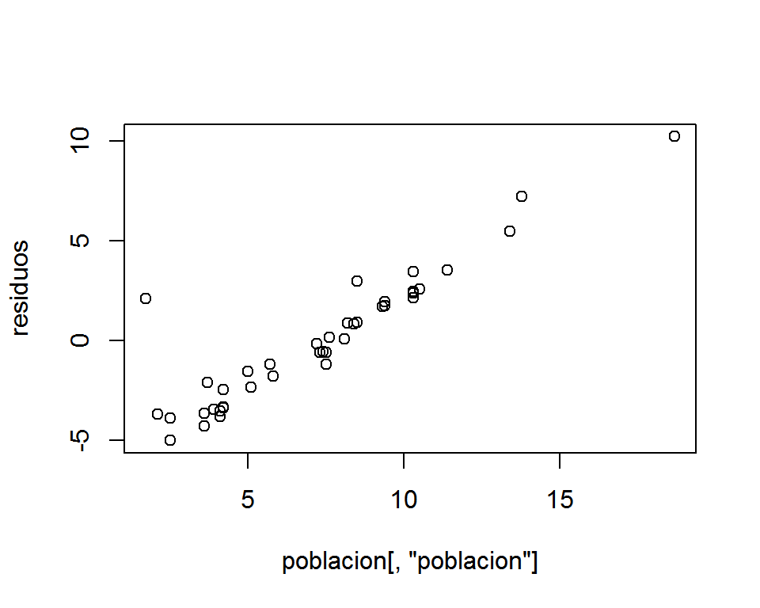

```r
plot(poblacion[,"poblacion"],residuos)
```

histograma

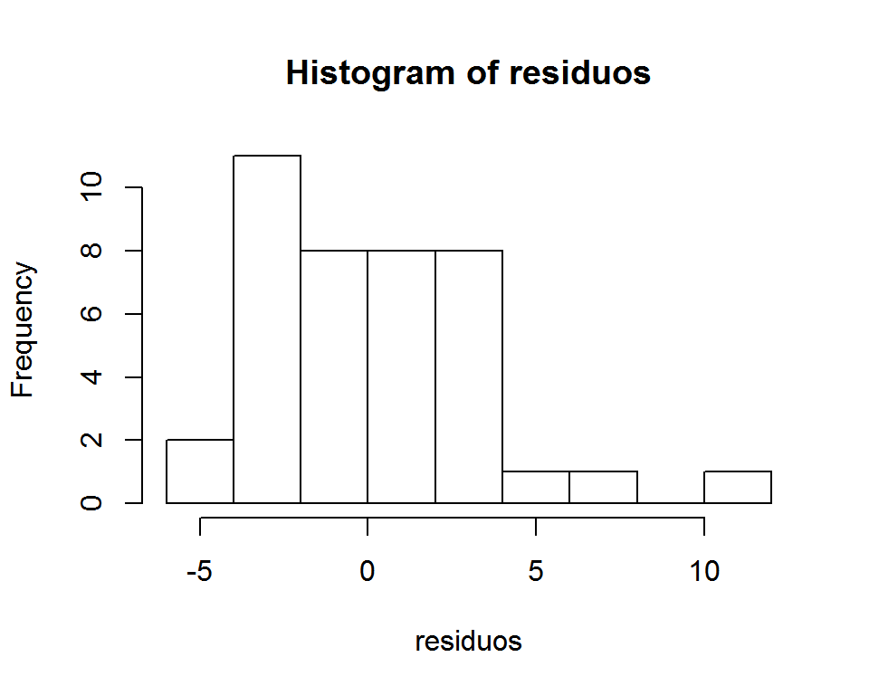

```r
hist(residuos)
```

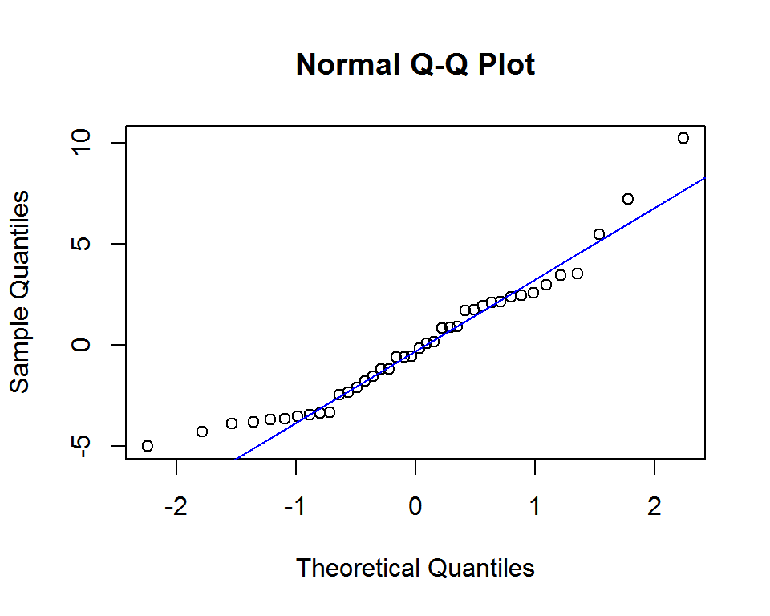

```r
qqnorm(residuos)
qqline(residuos,col="blue")
```